# Assignment 11

### Portfolio assignment 11

20 min: Do a Numerical VS Categorical bivariate analysis on the penguins dataset.

- Choose one of the categorical columns: species, island or sex
- use .groupby('').mean() too look at the means of the numerical columns. Does it look like there is a difference between categories?
- Use the seaborn barplot to plot the mean and confidence. Create this plot for each of the numerical columns (bill_length_mm bill_depth_mm, flipper_length_mm, body_mass_g)
- For each of the plots, write a conclusion: Is there a statistically significant difference for this numerical column for each category?
- Optional: Repeat this proces for the other two categorical columns

```python
import pandas as pd
import seaborn as sns
```

```python
penguins = sns.load_dataset('penguins')
penguins.head()
```

|  | species | island | bill_length_mm | bill_depth_mm | flipper_length_mm | body_mass_g | sex |
| --- | --- | --- | --- | --- | --- | --- | --- |
| 0 | Adelie | Torgersen | 39.1 | 18.7 | 181.0 | 3750.0 | Male |
| 1 | Adelie | Torgersen | 39.5 | 17.4 | 186.0 | 3800.0 | Female |
| 2 | Adelie | Torgersen | 40.3 | 18.0 | 195.0 | 3250.0 | Female |
| 3 | Adelie | Torgersen | NaN | NaN | NaN | NaN | NaN |
| 4 | Adelie | Torgersen | 36.7 | 19.3 | 193.0 | 3450.0 | Female |

I choose to checkout the Island category.

```python
penguins.groupby(by="island").mean()
```

| island | bill_length_mm | bill_depth_mm | flipper_length_mm | body_mass_g |
| --- | --- | --- | --- | --- |
| Biscoe | 45.257485 | 15.874850 | 209.706587 | 4716.017964 |
| Dream | 44.167742 | 18.344355 | 193.072581 | 3712.903226 |
| Torgersen | 38.950980 | 18.429412 | 191.196078 | 3706.372549 |

There are significant diffrences between these categories.

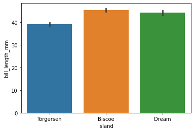

```python
sns.barplot(x="island", y="bill_length_mm", data=penguins)
```

The changes are subtle but there are changes. Biscoe island penguins have the longest bill length. Not too far behind is the Dream Island

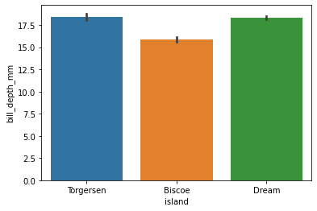

```python
sns.barplot(x="island", y="bill_depth_mm", data=penguins)
```

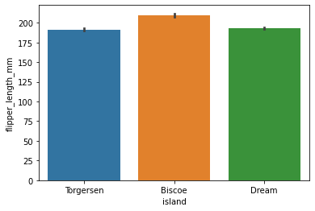

```python
sns.barplot(x="island", y="flipper_length_mm", data=penguins)
```

Now u can see that the Biscoe Island has the longest flipper length. Then the Dream island and as last the Torgersen

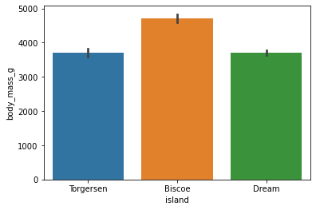

```python
sns.barplot(x="island", y="body_mass_g", data=penguins)
```